# Bayesian_Binom_and_MRP_hierarchical_raking_softmax_Poisson_KristineB_discont

## Import packages

Package installations are collected in different notebook.

```python
import numpy as np
import pandas as pd
from sklearn.preprocessing import StandardScaler
import arviz as az
import seaborn as sns
import matplotlib.pyplot as plt
from scipy.special import expit
import pymc as pm
import ipywidgets
import pytensor as pt
import graphviz
from scipy.stats import norm, t
#import openpyxl
from collections import Counter
from statistics import harmonic_mean
import pytensor.tensor as pt
import re
import itertools
from scipy.stats import beta
```

```python
run_model = False
```

```python
%run /mnt/batch/tasks/shared/LS_root/mounts/clusters/hus555425151/code/Users/Per_Tra_analysis/common_functions.py
```

```python
%run /mnt/batch/tasks/shared/LS_root/mounts/clusters/hus555425151/code/Users/Per_Tra_analysis/RCT_marginals.py
```

## Configurations

```python
%config InlineBackend.figure_format = 'retina'
az.style.use("arviz-whitegrid")
rng = np.random.default_rng(1234)
```

## Import data

```python
prefix_path = "/mnt/batch/tasks/shared/LS_root/mounts/clusters/hus555425151/code/"
per_tra = pd.read_csv(prefix_path + "Users/Per_Tra_analysis/per_tra_master_final.csv", sep=",")
NAT_kristine_helen_discont_comp = pd.read_csv(prefix_path + "Users/Per_Tra_analysis/Data/NAT_kristine_helen_discont_comp.csv", sep=",").rename(columns={"person_id":"Pseudo"})
per_tra = (per_tra
           .merge(NAT_kristine_helen_discont_comp
                  , on = "Pseudo"
                  , how = "left"
                 )
          )

per_tra["NAT_discontinuation"] = per_tra["finished_NAT"].map({True: False, False: True})
```

## Data wrangling

### Redefine variables

Each RCT has different table 1 and the variables hove to be modified accordingly. This is done with the data_wrangling function. Then the model variables are collected, factorized, the mapping are saved and put in the dictionaries so that they are easy to hande in the model.

```python
per_tra = data_wrangling(per_tra, target="Kristine")


X_age = per_tra["Age_group_med"]
X_biopsy_nodal_positive = per_tra["biopsy_nodal_positive"]
X_Tumor_size_status = per_tra['Tumor_size_status']
X_hormone_status = per_tra["hormone_status"]
X_bilateral = per_tra["Bilateral"]
X_NAT_discontinuation = per_tra["NAT_discontinuation"]
y = per_tra["pCR_or_not"]

age_idx, age_groups = pd.factorize(X_age, sort=True)
biopsy_nodal_positive_idx, biopsy_nodal_positive_groups = pd.factorize(X_biopsy_nodal_positive, sort=True)
Tumor_size_status_idx, Tumor_size_status_groups = pd.factorize(X_Tumor_size_status, sort=True)
hormone_status_idx, hormone_status_groups = pd.factorize(X_hormone_status, sort=True)
bilateral_idx, bilateral_groups = pd.factorize(X_bilateral, sort=True)
NAT_discontinuation_idx, NAT_discontinuation_groups = pd.factorize(X_NAT_discontinuation, sort=True)

age_map = {cat: i for i, cat in enumerate(age_groups)}
biopsy_nodal_positive_map = {cat: i for i, cat in enumerate(biopsy_nodal_positive_groups)}
Tumor_size_status_map = {cat: i for i, cat in enumerate(Tumor_size_status_groups)}
hormone_status_map = {cat: i for i, cat in enumerate(hormone_status_groups)}
bilateral_map = {cat: i for i, cat in enumerate(bilateral_groups)}
NAT_discontinuation_map = {cat: i for i, cat in enumerate(NAT_discontinuation_groups)}

pCR_idx, pCR_groups = pd.factorize(y, sort=True)

coords = {"Age_group_med": age_groups
          , "biopsy_nodal_positive": biopsy_nodal_positive_groups
          , "Tumor_size_status": Tumor_size_status_groups
          , "hormone_status":hormone_status_groups
          , "Bilateral":bilateral_groups
          , "NAT_discontinuation":NAT_discontinuation_groups

          #, "observations": pCR_idx
         }

idx_dict = {"Age_group_med": age_idx
          , "biopsy_nodal_positive": biopsy_nodal_positive_idx
          , "Tumor_size_status": Tumor_size_status_idx
          , "hormone_status":hormone_status_idx
          , "Bilateral":bilateral_idx
          , "NAT_discontinuation":NAT_discontinuation_idx
          }

# Make sure idx_dict[var] are plain int64 NumPy arrays (not Pandas, not object dtype)
idx_dict = {k: np.asarray(v, dtype="int64") for k, v in idx_dict.items()}
```

The model needs the contingency table and the loading matrix L for counting the marginals from the contingency table and they are created here. The raking sep also needs the variable indexies for the post-stratification, and they are provided here.

```python
raking_vars = list(coords.keys())
margin_formulas = [[x] for x in raking_vars]

L, poststrat_table, row_labels, col_labels, L_blocks = build_loading_matrix_from_data(data=per_tra, raking_vars=raking_vars, margin_formulas=margin_formulas, marg_dict=marginals_kristineB_discont)

age_poststrat_idx = poststrat_table["Age_group_med"].map(age_map)
biopsy_nodal_positive_poststrat_idx = poststrat_table["biopsy_nodal_positive"].map(biopsy_nodal_positive_map)
Tumor_size_status_poststrat_idx = poststrat_table["Tumor_size_status"].map(Tumor_size_status_map)
hormone_status_poststrat_idx = poststrat_table["hormone_status"].map(hormone_status_map)
bilateral_poststrat_idx = poststrat_table["Bilateral"].map(bilateral_map)
NAT_discontinuation_poststrat_idx = poststrat_table["NAT_discontinuation"].map(NAT_discontinuation_map)

idx_dict_postrat = {"Age_group_med": age_poststrat_idx
          , "biopsy_nodal_positive": biopsy_nodal_positive_poststrat_idx
          , "Tumor_size_status": Tumor_size_status_poststrat_idx
          , "hormone_status":hormone_status_poststrat_idx
          , "Bilateral":bilateral_poststrat_idx
          , "NAT_discontinuation":NAT_discontinuation_poststrat_idx
         }
```

The zero marginal rows (normally coming from the exclusion/inclusion criteria) are not needed because post-stratification should give the probability zero. We also want that the marginals are in the same order as the loading matrix L gives them, and the order is set here.

```python
marginals_kristineB_discont_trunc = {k:v for k,v in marginals_kristineB_discont.items() if v != 0}
marginals_kristineB_discont_trunc = {i:marginals_kristineB_discont_trunc[i] for i in row_labels}
```

## Parameters and data to the model

The model needs the contingency table's number vector N_org, target marginal blocks N_target_marginal_blocks, contingency table's vector's length C, number of marginal blocks to iterate over B, the sample size of the row-level data T_org, target N T_target, logarithmitized and normalized contingency vector log_q, pCR counts from both HUS and the RCT, and the comparison table from the pCR counts for the binomial model.

```python
# ---- Provide your data here ----
# N_org: (C,), N_marg: (K,), L: (K,C)
N_org   = poststrat_table["Freq"].to_numpy()
N_target_marg_blocks = marg_dict_to_blocks(marginals_kristineB_discont_trunc)
eps     = 1e-8

C = N_org.shape[0]
B = len(L_blocks)
T_org = int(N_org.sum())
T_target  = N_kristineB

# Original composition with epsilon-floor
q = N_org / T_org
q_star = np.maximum(q, eps)
q_star = q_star / q_star.sum()
log_q = np.log(np.maximum(q_star, 1e-12))

N_pCR_HUS = len(y[y==True])


#Combine the results in one table
comparison_table = pd.DataFrame([{"source":"kristine", "pCR_count":N_pCR_kristineB, "count":N_kristineB}, {"source":"HUS", "pCR_count":N_pCR_HUS, "count":len(y)}])

source = comparison_table["source"]
count = comparison_table["count"]
pCR_count = comparison_table["pCR_count"]

source_idx, source_groups = pd.factorize(source)
```

## The Model

Checking the model parameter dimensions and then defining the model.

```python
print("coords:", coords)
print("post_idx shapes:", {k: len(v) for k, v in idx_dict_postrat.items()})
print("N_target_marg_blocks lengths:", [len(b) for b in N_target_marg_blocks])
print("Loading matrices shapes:", [Lb.shape for Lb in L_blocks])
```

```
coords: {'Age_group_med': CategoricalIndex(['Under 49', 'Over 49'], categories=['Under 49', 'Over 49'], ordered=True, dtype='category'), 'biopsy_nodal_positive': Index(['False', 'True'], dtype='object'), 'Tumor_size_status': Index(['N/A', 'T1', 'T2-T3'], dtype='object'), 'hormone_status': Index(['Ne…
post_idx shapes: {'Age_group_med': 8, 'biopsy_nodal_positive': 8, 'Tumor_size_status': 8, 'hormone_status': 8, 'Bilateral': 8, 'NAT_discontinuation': 8}
N_target_marg_blocks lengths: [2, 1, 1, 2, 1, 2]
Loading matrices shapes: [(2, 8), (1, 8), (1, 8), (2, 8), (1, 8), (2, 8)]
```

```python
with pm.Model(coords=coords) as binom_mrp_rake_softmax_poisson:

    # ----------------------------
    # 1) Outcome model (hierarchical ANOVA logit)
    # ----------------------------
    # Global intercept
    beta0 = pm.Normal("beta0", 0.0, 1.5)

    # global slab scale for all factors
    g_beta = pm.HalfNormal("g_beta", sigma=0.7)

    # Factor level effects: Student-t(ν=4, 0, τ_k) with sum-to-zero within each factor
    beta_levels = {}
    for var, val in coords.items():
        # per-factor scale (gentle partial pooling)
        tau_var = pm.HalfNormal(f"tau_{var}", sigma=g_beta)

        # Uncentered raw effects
        #beta_raw = pm.StudentT(f"beta_raw_{var}", nu=4, mu=0.0, sigma=tau_dict[var], dims=var)
        beta_raw = pm.StudentT(f"beta_raw_{var}", nu=4, mu=0.0, sigma=tau_var, dims=var)
        # Enforce sum-to-zero across levels
        beta_k = pm.Deterministic(f"beta_{var}", beta_raw - pm.math.mean(beta_raw), dims=var)
        beta_levels[var] = beta_k

    # Linear predictor per person i: beta0 + sum_k beta_{k, idx_k[i]}
    # Gather all additive parts
    terms_outcome = [beta0] + [pt.take(beta_levels[var], idx_dict[var]) for var in coords.keys()]

    # Sum safely in one operation
    eta_outcome_i = pt.add(*terms_outcome)
    p_outcome_i = pm.Deterministic("p_outcome_i", pm.math.sigmoid(eta_outcome_i))

    # Outcome likelihood
    pm.Bernoulli("y", p=p_outcome_i, observed=pCR_idx)

    # ----------------------------
    # 2) Bayesian raking over joint cells
    # ----------------------------

    dev_scale = pm.HalfNormal("dev_scale", sigma=0.3)

    # ANOVA-style deviations per factor
    dev_cell = 0
    for var in coords.keys():
        # raw deviations per level
        dev_raw  = pm.Normal(
            f"dev_{var}_raw",
            mu=0.0,
            sigma=1.0,
            dims=var,
        )
        # sum-to-zero across levels
        dev_centered = dev_raw  - pm.math.mean(dev_raw )

        # map to poststrat cells
        dev_cell_var = dev_centered[idx_dict_postrat[var]]
        dev_cell = dev_cell + dev_scale * dev_cell_var


    eta_raw = log_q + dev_cell

    # remove additive non-identifiability
    eta = eta_raw - pm.math.mean(eta_raw)

    p_comp = pm.Deterministic("p_comp", pm.math.softmax(eta))

    Nhat = pm.Deterministic("Nhat", T_target * p_comp)


    # Poisson margins
    for b, (Lb, N_b) in enumerate(zip(L_blocks, N_target_marg_blocks)):
        mu_b = (pt.dot(Lb, Nhat) + eps)
        pm.Poisson(f"N_target_b{b}", mu=mu_b, observed=N_b)
    # ----------------------------
    # 3) Cell-level outcome probabilities
    # ----------------------------
    # Gather all additive parts
    terms_poststrat = [beta0] + [pt.take(beta_levels[var], idx_dict_postrat[var]) for var in coords.keys()]


    # Sum safely in one operation
    eta_poststrat_i = pt.add(*terms_poststrat)
    p_poststrat_i = pm.Deterministic("p_poststrat_i", pm.math.sigmoid(eta_poststrat_i))


    # ----------------------------
    # 4) Post-stratified estimands
    # ----------------------------
    # Overall target-population mean:
    theta_overall = pm.Deterministic("theta_overall", (p_poststrat_i * Nhat).sum() / Nhat.sum())

    # ----------------------------
    # 5) Binomial model for the observed pCR rates
    # ----------------------------
    # Uninformative beta priors
    binom_mrp_rake_softmax_poisson.add_coords({"source": source_groups})
    p_binom = pm.Beta("p_binom", alpha=1, beta=1, dims="source")

    #Difference between observed rates
    p_diff_obs = pm.Deterministic("p_diff_obs", p_binom[1]-p_binom[0])
    #Tähän asti ok
    #Likelihood
    pm.Binomial("pCR_count", n=count, p=p_binom, observed=pCR_count)

    #Difference between observed rates
    p_diff_counterfact = pm.Deterministic("p_diff_counterfact", p_binom[1]-theta_overall)
```

```python
if run_model:
    with binom_mrp_rake_softmax_poisson:
        idata = pm.sample( draws=3500
                           , tune=6000
                           #, target_accept=0.95
                           #, init="jitter+adapt_diag"
                           , chains = 3
                         , random_seed=rng)
        pm.sample_posterior_predictive(idata, extend_inferencedata=True, random_seed=rng)
        prior_samples = pm.sample_prior_predictive(100, random_seed=rng)
        pm.compute_log_likelihood(idata)
        az.to_netcdf(idata, prefix_path + "Users/Per_Tra_analysis/DATA/MCMC/binom_MRP_Raking_anova_softmax_kristineb_discont.nc")
        az.to_netcdf(prior_samples, prefix_path + "Users/Per_Tra_analysis/DATA/MCMC/binom_MRP_Raking_anova_softmax_kristineb_ppc_discont.nc")
else:
    idata = az.from_netcdf(prefix_path + "Users/Per_Tra_analysis/DATA/MCMC/binom_MRP_Raking_anova_softmax_kristineb_discont.nc")
    prior_samples = az.from_netcdf(prefix_path + "Users/Per_Tra_analysis/DATA/MCMC/binom_MRP_Raking_anova_softmax_kristineb_ppc_discont.nc")
```

# Prior Predictive Checks

Let's sample from the priors to check that they look as they should.

```python
# All prior random variables
all_prior_vars = list(prior_samples.prior.data_vars)

prior_beta_vars = [v for v in all_prior_vars if v.startswith("beta")]
print("Beta variables used in PPC:", prior_beta_vars)
```

```
Beta variables used in PPC: ['beta0', 'beta_raw_Tumor_size_status', 'beta_hormone_status', 'beta_raw_biopsy_nodal_positive', 'beta_biopsy_nodal_positive', 'beta_Tumor_size_status', 'beta_raw_NAT_discontinuation', 'beta_raw_Bilateral', 'beta_raw_Age_group_med', 'beta_Bilateral', 'beta_Age_group_med',…
```

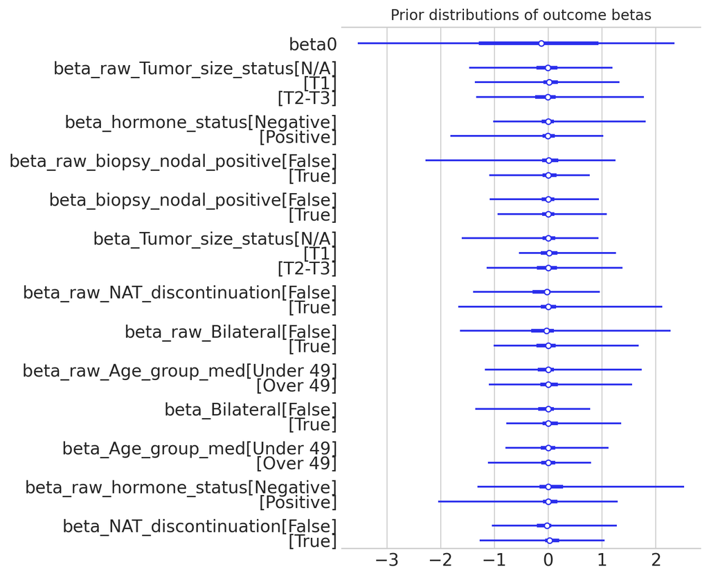

```python
def plot_prior_betas(prior_idata, beta_vars):
    """
    Plot prior distributions of all beta_* variables.
    """
    if not beta_vars:
        print("No beta_* variables found in prior.")
        return

    prior_idata_for_plot = prior_idata.copy()
    prior_idata_for_plot.posterior = prior_idata.prior

    az.plot_forest(
        prior_idata_for_plot,
        var_names=beta_vars,
        combined=True,  # combine chains
        figsize=(8, max(2, 0.5 * len(beta_vars))),
    )
    plt.title("Prior distributions of outcome betas", fontsize=12)
    plt.show()

plot_prior_betas(prior_samples, prior_beta_vars)
```

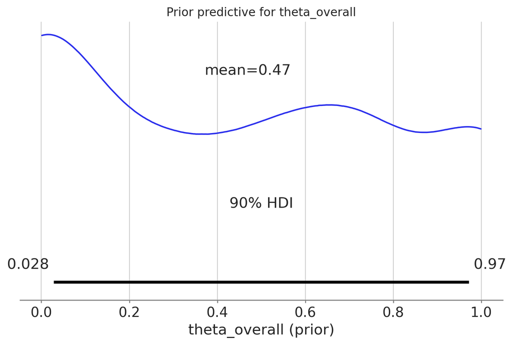

```python
def plot_prior_theta_overall(prior_idata):
    if "theta_overall" not in prior_idata.prior:
        print("theta_overall not found in prior_idata.prior")
        return

    prior_idata_for_plot = prior_idata.copy()
    prior_idata_for_plot.posterior = prior_idata.prior

    az.plot_posterior(
        prior_idata_for_plot,
        var_names=["theta_overall"],
        hdi_prob=0.9,
    )
    plt.title("Prior predictive for theta_overall", fontsize=12)
    plt.xlabel("theta_overall (prior)")
    plt.show()

plot_prior_theta_overall(prior_samples)
```

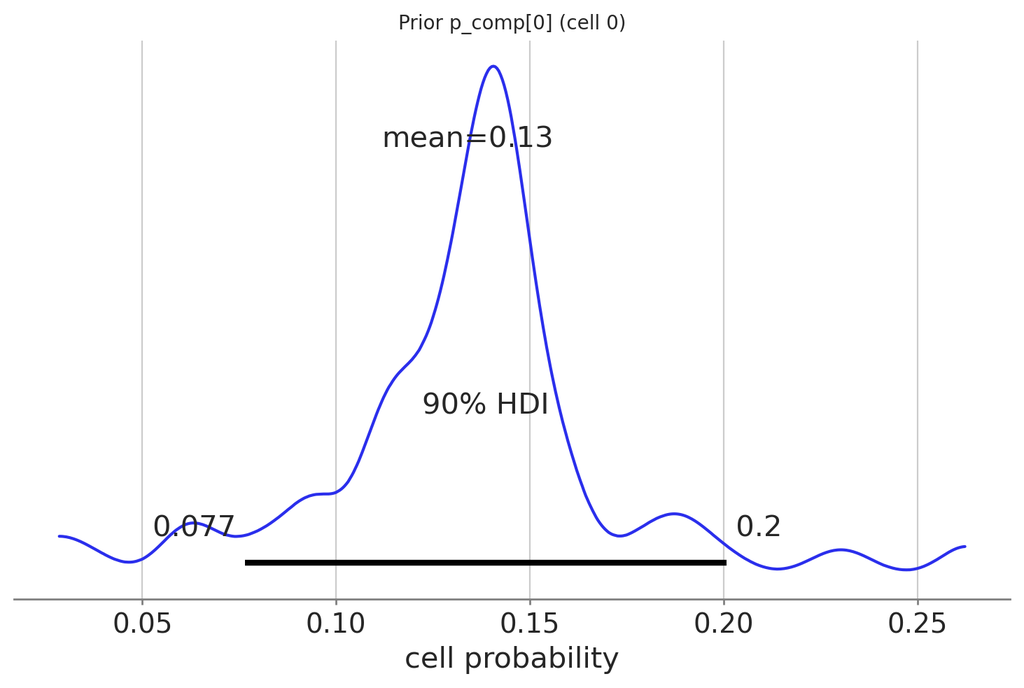

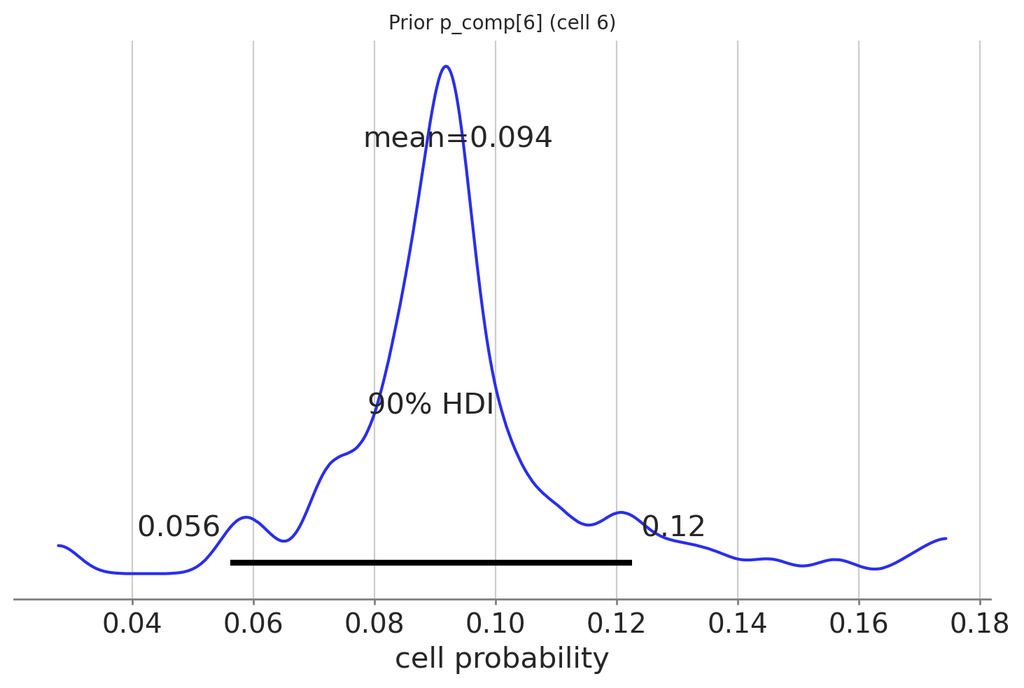

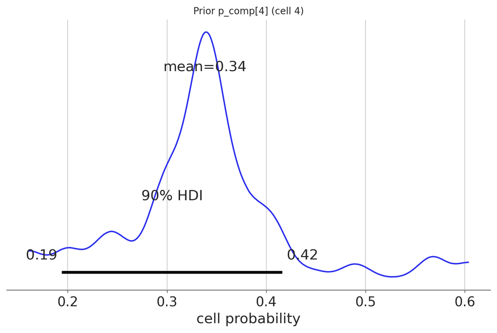

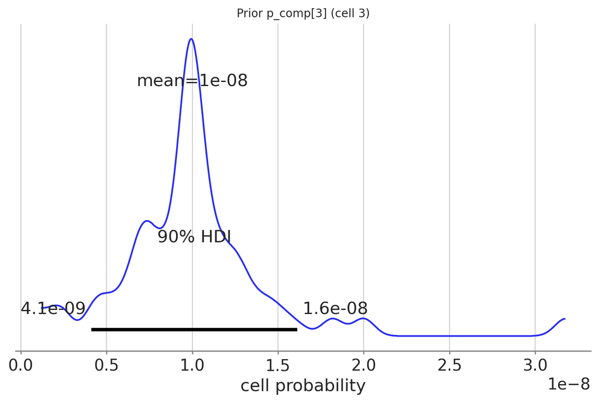

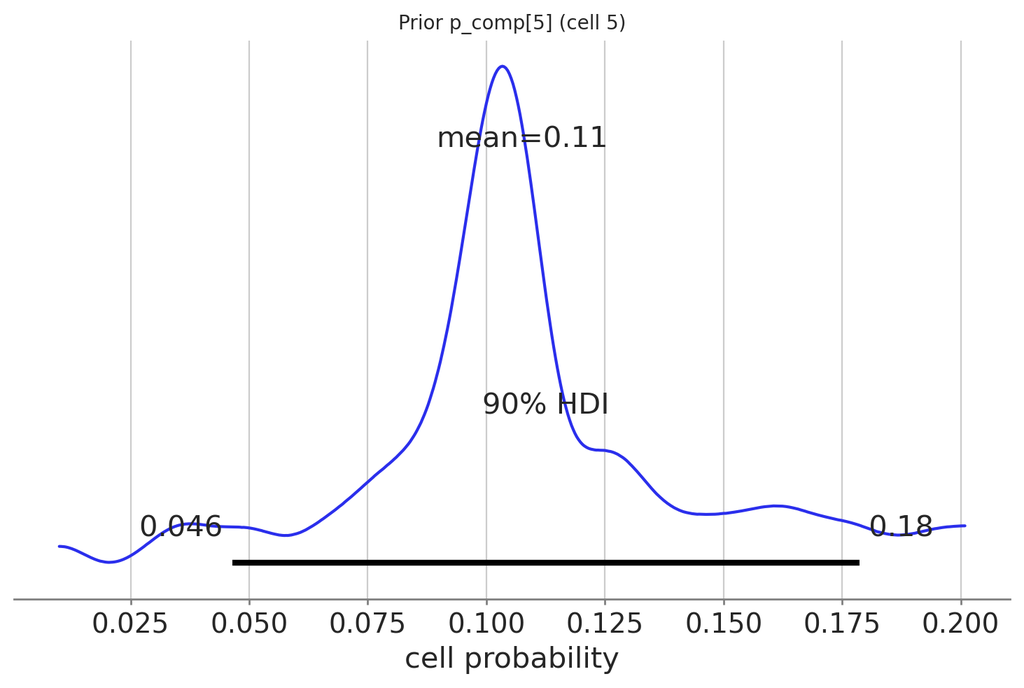

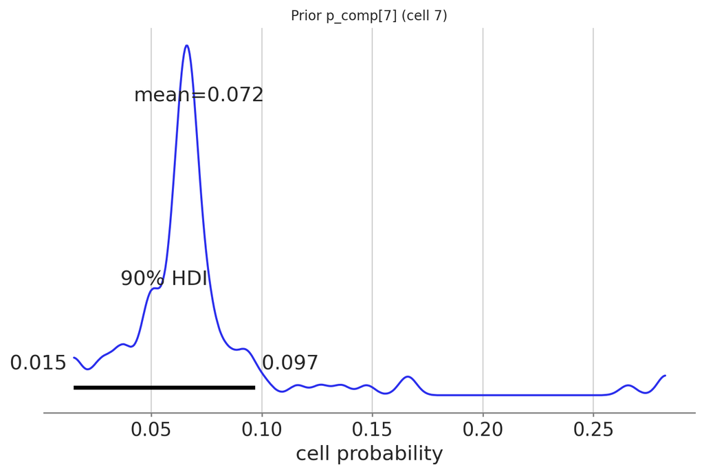

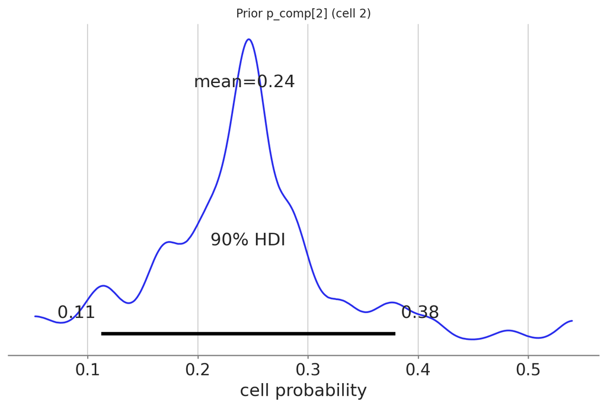

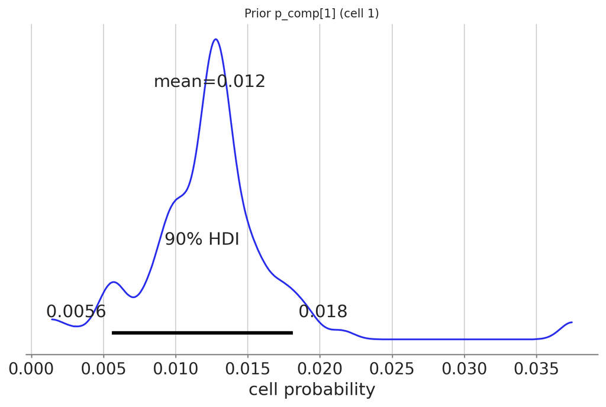

```python
def plot_prior_p_comp(prior_idata, n_cells_to_show=10):
    if "p_comp" not in prior_idata.prior:
        print("p_comp not found in prior_idata.prior")
        return


    p_prior = prior_idata.prior["p_comp"]  # shape: (chain, draw, C)
    C = p_prior.shape[-1]

    # Pick some random cell indices
    rng = np.random.default_rng(123)
    idx = rng.choice(C, size=min(n_cells_to_show, C), replace=False)

    for c in idx:
        samples = p_prior.sel(p_comp_dim_0=c).values.flatten()
        az.plot_posterior(samples, hdi_prob=0.9)
        plt.title(f"Prior p_comp[{c}] (cell {c})", fontsize=10)
        plt.xlabel("cell probability")
        plt.show()

plot_prior_p_comp(prior_samples, n_cells_to_show=8)
```

```python
def plot_prior_margins_from_Nhat(prior_idata, L_blocks, block_names=None, n_samples=200):
    """
    For each margin block, compute L_b @ Nhat for prior samples,
    and plot the prior predictive distribution of each margin level.
    """
    if "Nhat" not in prior_idata.prior:
        print("Nhat not found in prior_idata.prior")
        return

    Nhat_prior = prior_idata.prior["Nhat"]  # (chain, draw, C)
    chains, draws, C = Nhat_prior.shape

    # Stack chains & draws
    Nhat_flat = Nhat_prior.stack(sample=("chain", "draw")).values  # (C, S)
    S = Nhat_flat.shape[1]

    # Optionally limit number of samples for speed
    if S > n_samples:
        idx = np.random.default_rng(123).choice(S, Tumor_size_status=n_samples, replace=False)
        Nhat_flat = Nhat_flat[:, idx]
        S = n_samples

    for b, Lb in enumerate(L_blocks):

        if Lb.shape[0] < 2:
            continue
        else:
            block_label = block_names[b] if block_names is not None else f"block {b}"

            # Nhat_b: (K_b, S)
            Nhat_b = Lb @ Nhat_flat

            K_b = Nhat_b.shape[0]
            print(f"\nPrior predictive margins for {block_label}:")

            for k in range(K_b):
                samples = Nhat_b[k, :]
                az.plot_posterior(samples, hdi_prob=0.9)
                plt.title(f"{block_label}, level {k} (prior predictive)", fontsize=10)
                plt.xlabel("Margin count")
                plt.show()
```

```
Prior predictive margins for block 0:
```

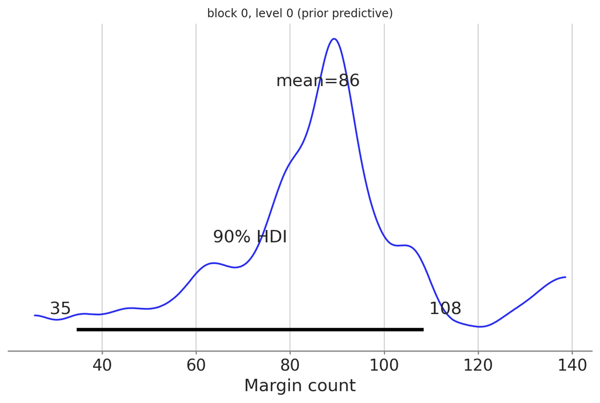

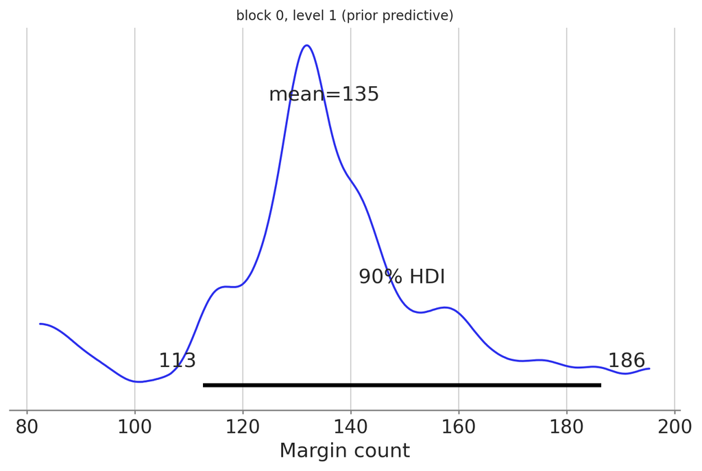

```
Prior predictive margins for block 3:
```

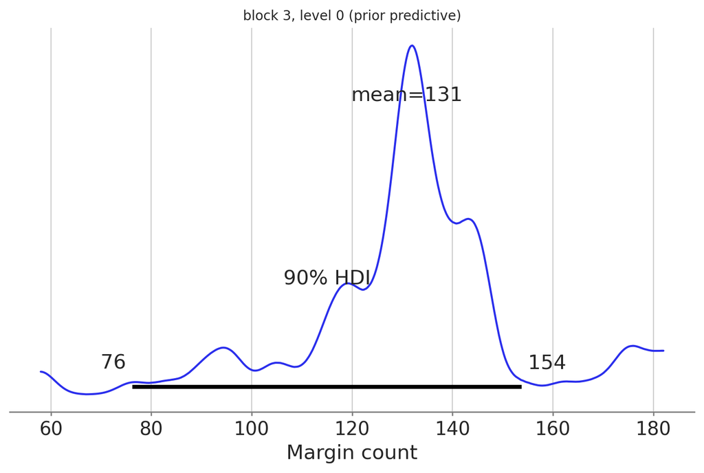

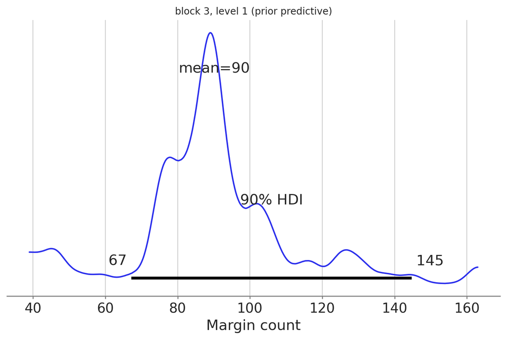

```
Prior predictive margins for block 5:
```

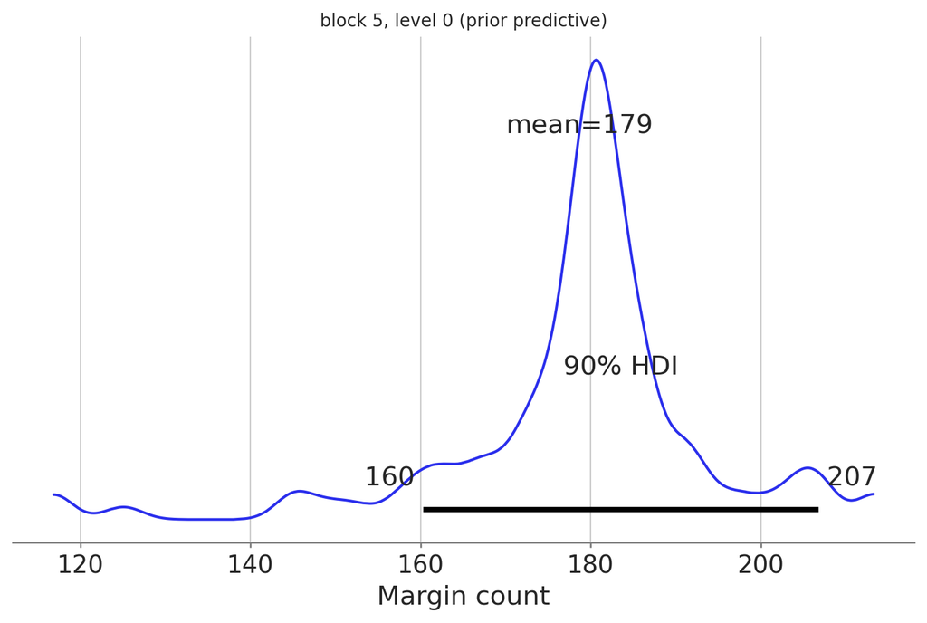

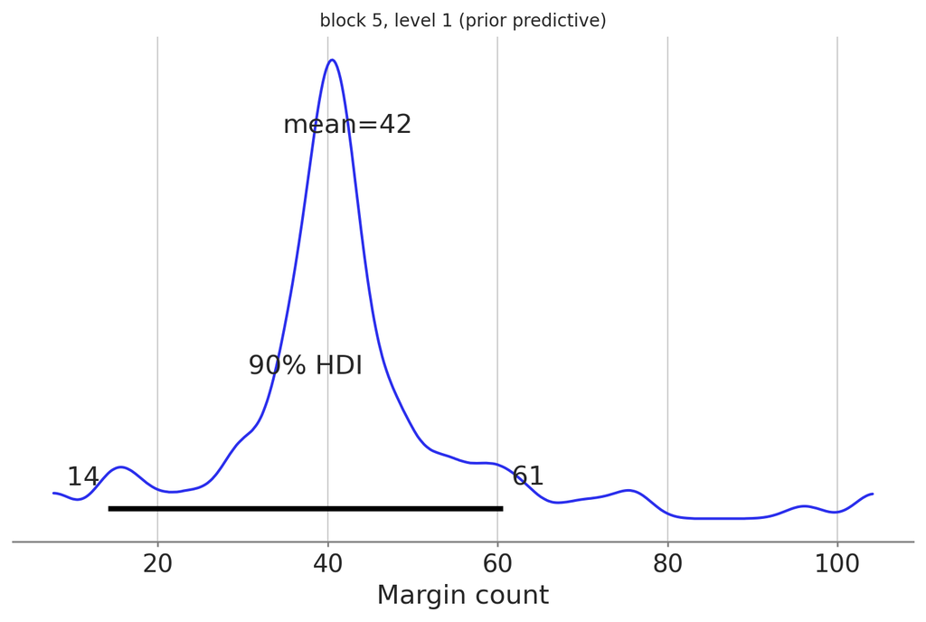

```python
plot_prior_margins_from_Nhat(prior_samples, L_blocks, block_names=None)
```

## Diagnostics

Let's check that the MCMCs have converged and the BFMI is ok.

```python
dict_clear_var_names = {'beta_Age_group_med':'beta_age_group_med'
                        , 'beta_biopsy_nodal_positive':'beta_biopsy_nodal_positive_preop'
                        , 'beta_Tumor_size_status':'beta_tumor_size_class_preop'
                        , 'beta_hormone_status':'beta_hormone_status_preop'
                        , 'beta_Bilateral':'beta_bilateral'
                        , 'beta_NAT_discontinuation':'beta_NAT_discontinuation'
}

idata_paper = idata.copy()  # cheap, doesn’t duplicate arrays
idata_paper = idata_paper.rename_vars(dict_clear_var_names)
```

```python
# Full list
all_vars = list(idata.posterior.data_vars)
print("All variables:", all_vars)

# Common groups
#core_vars = ["beta0", "g"]
core_vars = ["beta0"]
group_vars = [v for v in all_vars if v.startswith("tau_")]
effect_vars = [v for v in all_vars if v.startswith("beta_")]
rake_vars = ["eta", 'p_outcome_i']
theta_overall = ["theta_overall"]
nhat_vars = ['Nhat']
pCR_rate_vars = ["p_binom"]
pCR_rate_comp_vars = ["p_diff_obs", "p_diff_counterfact"]

#Renamed variables for the paper
all_vars_paper = list(idata_paper.posterior.data_vars)
effect_vars_paper = [v for v in all_vars_paper if (v.startswith("beta_")) & (~v.startswith("beta_raw"))]
```

```
All variables: ['beta0', 'beta_raw_Age_group_med', 'beta_raw_biopsy_nodal_positive', 'beta_raw_Tumor_size_status', 'beta_raw_hormone_status', 'beta_raw_Bilateral', 'beta_raw_NAT_discontinuation', 'dev_Age_group_med_raw', 'dev_biopsy_nodal_positive_raw', 'dev_Tumor_size_status_raw', 'dev_hormone_stat…
```

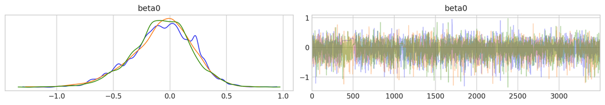

```python
az.plot_trace(idata, var_names=core_vars, compact=False);
```

[output not shown]

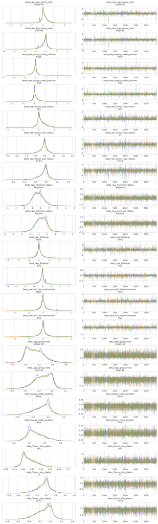

```python
az.plot_trace(idata, var_names=effect_vars, compact=False)
```

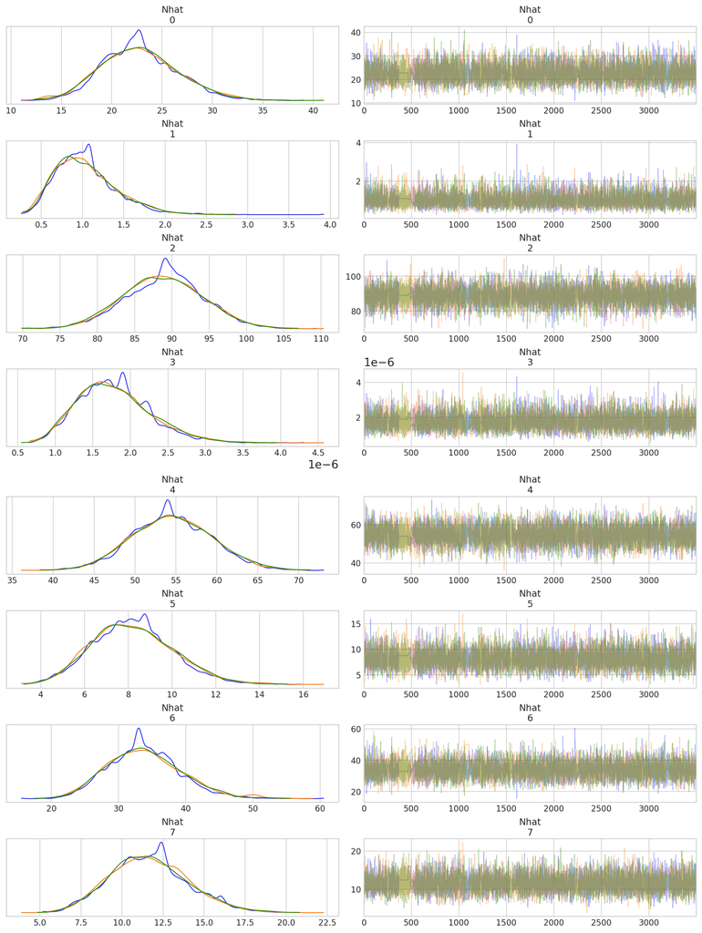

```python
az.plot_trace(idata, var_names=["Nhat"], compact=False);
```

```
array([[<Axes: title={'center': 'theta_overall'}>,
        <Axes: title={'center': 'theta_overall'}>]], dtype=object)
```

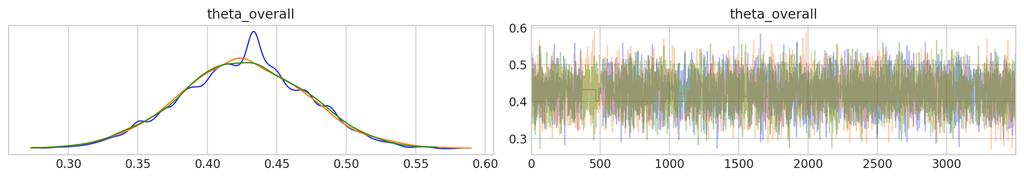

```python
az.plot_trace(idata, var_names=theta_overall, compact=False)
```

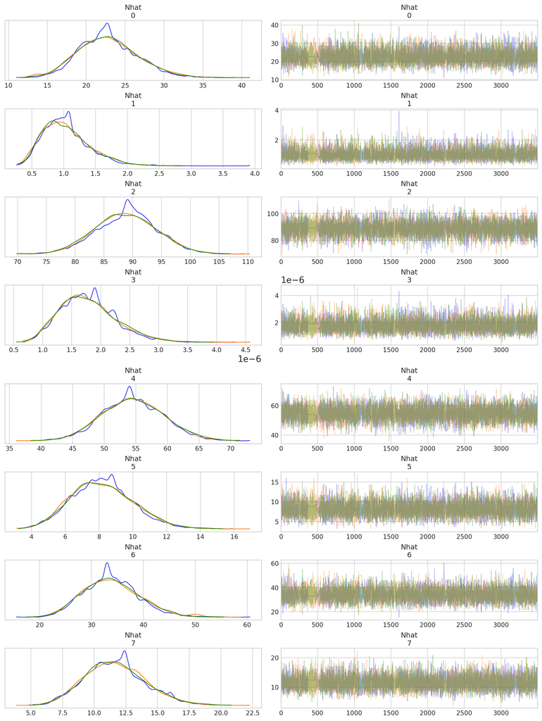

```python
az.plot_trace(idata, var_names=nhat_vars, compact=False);
```

```
array([[<Axes: title={'center': 'p_binom\nkristine'}>,
        <Axes: title={'center': 'p_binom\nkristine'}>],
       [<Axes: title={'center': 'p_binom\nHUS'}>,
        <Axes: title={'center': 'p_binom\nHUS'}>]], dtype=object)
```

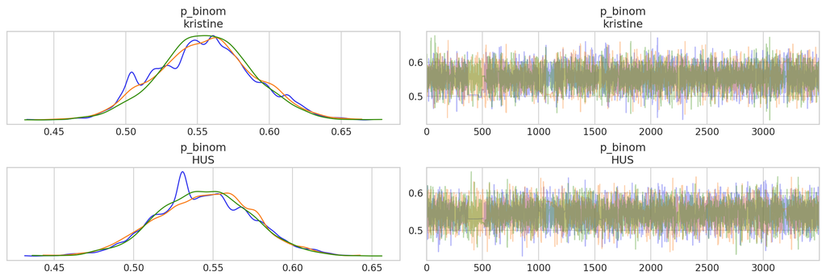

```python
az.plot_trace(idata, var_names=pCR_rate_vars, compact=False)
```

```
array([[<Axes: title={'center': 'p_diff_obs'}>,
        <Axes: title={'center': 'p_diff_obs'}>],
       [<Axes: title={'center': 'p_diff_counterfact'}>,
        <Axes: title={'center': 'p_diff_counterfact'}>]], dtype=object)
```

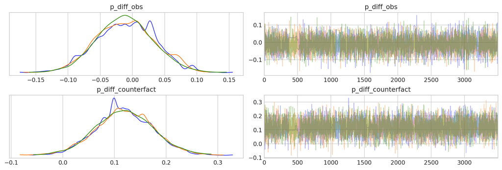

```python
az.plot_trace(idata, var_names=pCR_rate_comp_vars, compact=False)
```

```python
az.summary(idata, kind="diagnostics", var_names=core_vars)
```

|  | mcse_mean | mcse_sd | ess_bulk | ess_tail | r_hat |
| --- | --- | --- | --- | --- | --- |
| beta0 | 0.005 | 0.004 | 2791.0 | 3710.0 | 1.0 |

```python
#az.summary(idata, kind="diagnostics", var_names=group_vars)
```

```python
az.summary(idata, kind="diagnostics", var_names=effect_vars )
```

|  | mcse_mean | mcse_sd | ess_bulk | ess_tail | r_hat |
| --- | --- | --- | --- | --- | --- |
| beta_raw_Age_group_med[Under 49] | 0.011 | 0.023 | 1486.0 | 2049.0 | 1.0 |
| beta_raw_Age_group_med[Over 49] | 0.012 | 0.025 | 1527.0 | 1550.0 | 1.0 |
| beta_raw_biopsy_nodal_positive[False] | 0.006 | 0.013 | 3930.0 | 2872.0 | 1.0 |
| beta_raw_biopsy_nodal_positive[True] | 0.006 | 0.014 | 4066.0 | 2760.0 | 1.0 |
| beta_raw_Tumor_size_status[N/A] | 0.006 | 0.006 | 2888.0 | 3533.0 | 1.0 |
| beta_raw_Tumor_size_status[T1] | 0.005 | 0.008 | 3118.0 | 2526.0 | 1.0 |
| beta_raw_Tumor_size_status[T2-T3] | 0.006 | 0.009 | 2708.0 | 2246.0 | 1.0 |
| beta_raw_hormone_status[Negative] | 0.010 | 0.012 | 4680.0 | 3740.0 | 1.0 |
| beta_raw_hormone_status[Positive] | 0.011 | 0.013 | 4185.0 | 3972.0 | 1.0 |
| beta_raw_Bilateral[False] | 0.007 | 0.011 | 3242.0 | 3375.0 | 1.0 |
| beta_raw_Bilateral[True] | 0.007 | 0.012 | 2535.0 | 3244.0 | 1.0 |
| beta_raw_NAT_discontinuation[False] | 0.007 | 0.012 | 2228.0 | 2200.0 | 1.0 |
| beta_raw_NAT_discontinuation[True] | 0.006 | 0.011 | 2975.0 | 2582.0 | 1.0 |
| beta_Age_group_med[Under 49] | 0.002 | 0.001 | 2958.0 | 4608.0 | 1.0 |
| beta_Age_group_med[Over 49] | 0.002 | 0.001 | 2958.0 | 4608.0 | 1.0 |
| beta_biopsy_nodal_positive[False] | 0.002 | 0.001 | 4779.0 | 5605.0 | 1.0 |
| beta_biopsy_nodal_positive[True] | 0.002 | 0.001 | 4779.0 | 5605.0 | 1.0 |
| beta_Tumor_size_status[N/A] | 0.004 | 0.003 | 2826.0 | 4308.0 | 1.0 |
| beta_Tumor_size_status[T1] | 0.002 | 0.002 | 4769.0 | 5112.0 | 1.0 |
| beta_Tumor_size_status[T2-T3] | 0.002 | 0.002 | 4098.0 | 6042.0 | 1.0 |
| beta_hormone_status[Negative] | 0.002 | 0.001 | 3631.0 | 2862.0 | 1.0 |
| beta_hormone_status[Positive] | 0.002 | 0.001 | 3631.0 | 2862.0 | 1.0 |
| beta_Bilateral[False] | 0.005 | 0.004 | 1547.0 | 297.0 | 1.0 |
| beta_Bilateral[True] | 0.005 | 0.004 | 1547.0 | 289.0 | 1.0 |
| beta_NAT_discontinuation[False] | 0.002 | 0.002 | 4015.0 | 3017.0 | 1.0 |
| beta_NAT_discontinuation[True] | 0.002 | 0.002 | 4015.0 | 3017.0 | 1.0 |

```python
az.summary(idata, kind="diagnostics", var_names=["Nhat"])
```

|  | mcse_mean | mcse_sd | ess_bulk | ess_tail | r_hat |
| --- | --- | --- | --- | --- | --- |
| Nhat[0] | 0.050 | 0.058 | 5604.0 | 2698.0 | 1.0 |
| Nhat[1] | 0.005 | 0.005 | 5425.0 | 2807.0 | 1.0 |
| Nhat[2] | 0.057 | 0.058 | 8782.0 | 5510.0 | 1.0 |
| Nhat[3] | 0.000 | 0.000 | 5823.0 | 5036.0 | 1.0 |
| Nhat[4] | 0.061 | 0.045 | 6382.0 | 6572.0 | 1.0 |
| Nhat[5] | 0.023 | 0.019 | 6363.0 | 5950.0 | 1.0 |
| Nhat[6] | 0.080 | 0.107 | 5260.0 | 2873.0 | 1.0 |
| Nhat[7] | 0.029 | 0.025 | 6656.0 | 4587.0 | 1.0 |

```python
az.summary(idata, kind="diagnostics", var_names=pCR_rate_comp_vars)
```

|  | mcse_mean | mcse_sd | ess_bulk | ess_tail | r_hat |
| --- | --- | --- | --- | --- | --- |
| p_diff_obs | 0.001 | 0.001 | 2179.0 | 950.0 | 1.0 |
| p_diff_counterfact | 0.001 | 0.001 | 5097.0 | 6372.0 | 1.0 |

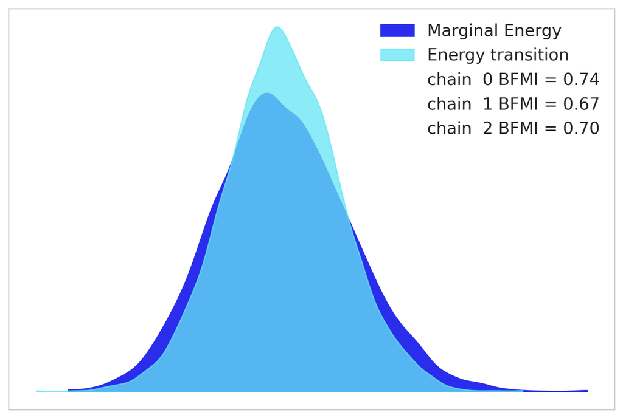

```python
az.plot_energy(idata)
```

# Model results

## The outcome model cofficients

```python
summ = az.summary(idata_paper, kind="stats", var_names=effect_vars_paper,round_to=2)
```

```python
summ
```

|  | mean | sd | hdi_3% | hdi_97% |
| --- | --- | --- | --- | --- |
| beta_age_group_med[Under 49] | 0.14 | 0.13 | -0.07 | 0.38 |
| beta_age_group_med[Over 49] | -0.14 | 0.13 | -0.38 | 0.07 |
| beta_biopsy_nodal_positive_preop[False] | -0.08 | 0.11 | -0.30 | 0.10 |
| beta_biopsy_nodal_positive_preop[True] | 0.08 | 0.11 | -0.10 | 0.30 |
| beta_tumor_size_class_preop[N/A] | 0.18 | 0.20 | -0.11 | 0.59 |
| beta_tumor_size_class_preop[T1] | -0.06 | 0.16 | -0.39 | 0.23 |
| beta_tumor_size_class_preop[T2-T3] | -0.12 | 0.15 | -0.43 | 0.10 |
| beta_hormone_status_preop[Negative] | 0.71 | 0.15 | 0.45 | 0.99 |
| beta_hormone_status_preop[Positive] | -0.71 | 0.15 | -0.99 | -0.45 |
| beta_bilateral[False] | 0.09 | 0.23 | -0.30 | 0.60 |
| beta_bilateral[True] | -0.09 | 0.23 | -0.60 | 0.30 |
| beta_NAT_discontinuation[False] | 0.01 | 0.11 | -0.21 | 0.24 |
| beta_NAT_discontinuation[True] | -0.01 | 0.11 | -0.24 | 0.21 |

```python
summ.to_latex(prefix_path + "Users/Per_Tra_analysis/Data/outcome_posterior_summary_kristineb_discont.tex")
```

## pCR rate means for the RCT and HUS and the estimated differences, incl the difference between the HUS pCR rate and the counterfactual (corresponding the -(adf_diff)).

```python
summ_binom = az.summary(idata, kind="stats", var_names=pCR_rate_vars,round_to=2)
```

```python
summ_binom
```

|  | mean | sd | hdi_3% | hdi_97% |
| --- | --- | --- | --- | --- |
| p_binom[kristine] | 0.56 | 0.03 | 0.49 | 0.62 |
| p_binom[HUS] | 0.54 | 0.03 | 0.49 | 0.60 |

```python
summ_binom.to_latex(prefix_path + "Users/Per_Tra_analysis/Data/binom_posterior_summary_kristineb_discont.tex")
```

```python
summ_deriv = az.summary(idata, kind="stats", var_names=pCR_rate_comp_vars,round_to=2)
```

```python
summ_deriv
```

|  | mean | sd | hdi_3% | hdi_97% |
| --- | --- | --- | --- | --- |
| p_diff_obs | -0.01 | 0.04 | -0.09 | 0.07 |
| p_diff_counterfact | 0.12 | 0.06 | 0.01 | 0.22 |

```python
summ_deriv.to_latex(prefix_path + "Users/Per_Tra_analysis/Data/derived_posterior_summary_kristineb_discont.tex")
```

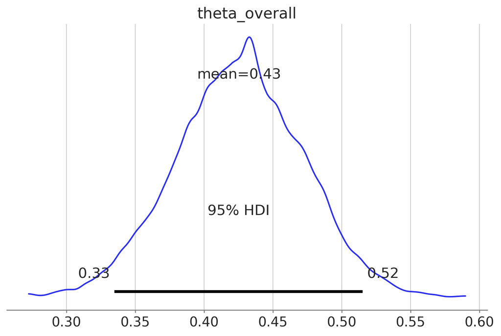

```python
az.plot_posterior(
    idata,
    var_names=["theta_overall"],
    point_estimate="mean",
    hdi_prob=0.95
)

plt.title(f"theta_overall")
plt.show()
```

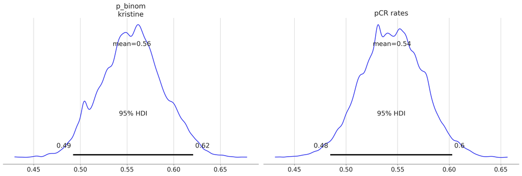

```python
az.plot_posterior(
    idata,
    var_names=pCR_rate_vars,
    point_estimate="mean",
    hdi_prob=0.95
)

plt.title(f"pCR rates")
plt.show()
```

[output not shown]

```python
p_diff_obs = idata.posterior.stack(sample=['chain', 'draw'])["p_diff_obs"]
p_diff_hus_counterfact = idata.posterior.stack(sample=['chain', 'draw'])["p_diff_counterfact"]

p_kristineB = idata.posterior.stack(sample=['chain', 'draw'])["p_binom"][0]
p_HUS = idata.posterior.stack(sample=['chain', 'draw'])["p_binom"][1]
p_counterfact = idata.posterior.stack(sample=['chain', 'draw'])["theta_overall"]

p_diff_counterfact_kristineB = p_counterfact - p_kristineB

print("Probability that HUS pCR rate is higher than in HelenB")
print(np.round(len(p_diff_obs[p_diff_obs>0])/len(p_diff_obs),2))
print("Probability that HUS pCR rate is higher than in RCT in practically meaningful way (more than 5%)")
print(np.round(len(p_diff_obs[p_diff_obs>0.05])/len(p_diff_obs),2))
print("Probability that RCT pCR rate is higher than in HUS")
print(np.round(len(p_diff_obs[p_diff_obs<0])/len(p_diff_obs),2))
print("Probability that RCT pCR rate is higher than in HUS in practically meaningful way (more than 5%)")
print(np.round(len(p_diff_obs[p_diff_obs<-0.05])/len(p_diff_obs),2))

print("Probability that the HUS pCR rate is higher than in countrfactual")
print(np.round(len(p_diff_hus_counterfact[p_diff_hus_counterfact>0])/len(p_diff_hus_counterfact),2))
print("Probability that the HUS pCR rate is higher than in countrfactual in practically meaningful way (more than 5%)")
print(np.round(len(p_diff_hus_counterfact[p_diff_hus_counterfact>0.05])/len(p_diff_hus_counterfact),2))
print("Probability that the counterfactual pCR rate is higher than in HUS")
print(np.round(len(p_diff_hus_counterfact[p_diff_hus_counterfact<0])/len(p_diff_hus_counterfact),2))
print("Probability that the counterfactual pCR rate is higher than in HUS in practically meaningful way (more than 5%)")
print(np.round(len(p_diff_hus_counterfact[p_diff_hus_counterfact<-0.05])/len(p_diff_hus_counterfact),2))

print("Probability that the countrfactual pCR rate is higher than in kristineB")
print(np.round(len(p_diff_counterfact_kristineB[p_diff_counterfact_kristineB>0])/len(p_diff_counterfact_kristineB),2))
print("Probability that the countrfactual pCR rate is higher than in kristineB in practically meaningful way (more than 5%)")
print(np.round(len(p_diff_counterfact_kristineB[p_diff_counterfact_kristineB>0.05])/len(p_diff_counterfact_kristineB),2))
print("Probability that the kristineB pCR rate is higher than in counterfactual")
print(np.round(len(p_diff_counterfact_kristineB[p_diff_counterfact_kristineB<0])/len(p_diff_counterfact_kristineB),2))
print("Probability that the kristineB pCR rate is higher than in counterfactual in practically meaningful way (more than 5%)")
print(np.round(len(p_diff_counterfact_kristineB[p_diff_counterfact_kristineB<-0.05])/len(p_diff_counterfact_kristineB),2))
```

```
Probability that HUS pCR rate is higher than in HelenB
0.41
Probability that HUS pCR rate is higher than in RCT in practically meaningful way (more than 5%)
0.09
Probability that RCT pCR rate is higher than in HUS
0.59
Probability that RCT pCR rate is higher than in HUS in practically meaningful way (more than 5%)
0.19
Probability that the HUS pCR rate is higher than in countrfactual
0.98
Probability that the HUS pCR rate is higher than in countrfactual in practically meaningful way (more than 5%)
0.9
Probability that the counterfactual pCR rate is higher than in HUS
0.02
Probability that the counterfactual pCR rate is higher than in HUS in practically meaningful way (more than 5%)
0.0
Probability that the countrfactual pCR rate is higher than in kristineB
0.01
Probability that the countrfactual pCR rate is higher than in kristineB in practically meaningful way (more than 5%)
0.0
Probability that the kristineB pCR rate is higher than in counterfactual
0.99
Probability that the kristineB pCR rate is higher than in counterfactual in practically meaningful way (more than 5%)
0.92
```

## Posterior for the theta_hus, theta_RCT and theta_{RWD -> RCT}

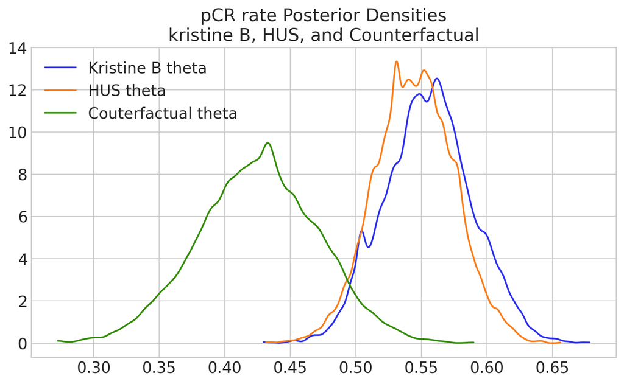

```python
# Suppose idata is your inference dataset
# idata.posterior["p_binom"] has shape (chain, draw, 2)
p = idata.posterior["p_binom"].values
p0 = p[..., 0].flatten()
p1 = p[..., 1].flatten()

theta = idata.posterior["theta_overall"].values.flatten()

fig, ax = plt.subplots(figsize=(8, 5))

# Plot each distribution on the same axes
az.plot_kde(p0, ax=ax, label="Kristine B theta", plot_kwargs={"color": "C0"})
az.plot_kde(p1, ax=ax, label="HUS theta", plot_kwargs={"color": "C1"})
az.plot_kde(theta, ax=ax, label="Couterfactual theta", plot_kwargs={"color": "C2"})

ax.legend()
ax.set_title("pCR rate Posterior Densities\nkristine B, HUS, and Counterfactual")

fig.tight_layout()

plt.show()

fig.savefig(prefix_path + "Users/Per_Tra_analysis/Images/kristineB_posterior_comp_discont.pdf",
            bbox_inches="tight",
            facecolor="white")
plt.close()
```

## Posteriors for the residual and adjustment differences

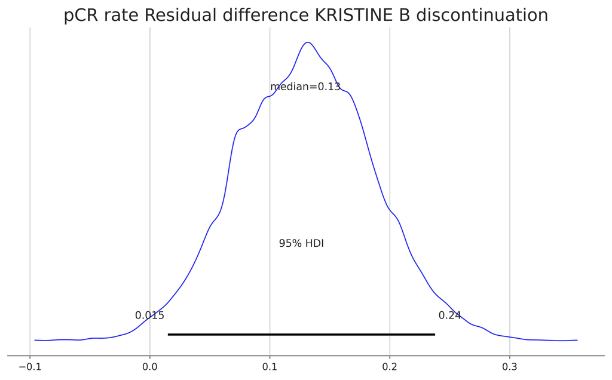

```python
import textwrap
import xarray as xr


diff_res = p0 - theta.flatten()


diff_res = np.asarray(diff_res)
if diff_res.ndim == 1:
    diff_res = diff_res[None, :]          # (chain, draw) expected by ArviZ

diff_res = xr.DataArray(diff_res, dims=("chain", "draw"), name="")  # empty name

fig, ax = plt.subplots(figsize=(8, 5), dpi=300)

az.plot_posterior(
    diff_res,
    kind="kde",
    hdi_prob=0.95,
    point_estimate="median",   # or None if you want no median annotation
    ax=ax,
    textsize=9                 # key: controls ArviZ annotation sizes

)

# Paper-friendly x-label that won’t run outside margins:
label = "pCR rate Residual difference KRISTINE B discontinuation"  # your label here
ax.set_title(label)  # wraps long labels nicely



fig.tight_layout()

fig.savefig(prefix_path + "Users/Per_Tra_analysis/Images/kristineB_res_diff_discont.pdf",
            bbox_inches="tight",
            facecolor="white")
```

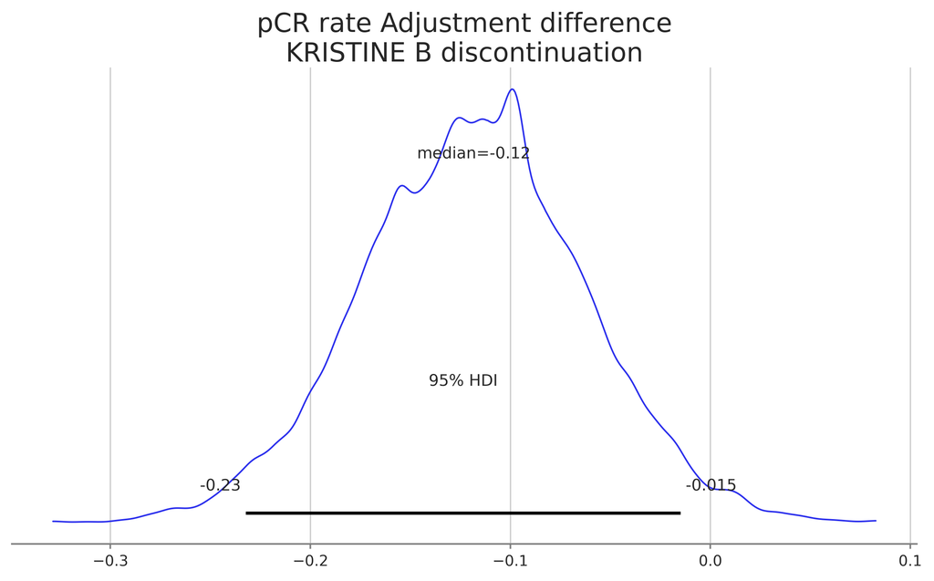

```python
diff_adj = theta.flatten() - p1

diff_adj = np.asarray(diff_adj)
if diff_adj.ndim == 1:
    diff_adj = diff_adj[None, :]          # (chain, draw) expected by ArviZ

diff_adj = xr.DataArray(diff_adj, dims=("chain", "draw"), name="")  # empty name

fig, ax = plt.subplots(figsize=(8, 5), dpi=300)

az.plot_posterior(
    diff_adj,
    kind="kde",
    hdi_prob=0.95,
    point_estimate="median",   # or None if you want no median annotation
    ax=ax,
    textsize=9                 # key: controls ArviZ annotation sizes
)

# Paper-friendly x-label that won’t run outside margins:
xlabel = "pCR rate Adjustment difference KRISTINE B discontinuation"  # your label here
ax.set_title(textwrap.fill(xlabel, width=35))  # wraps long labels nicely



fig.tight_layout()

fig.savefig(prefix_path + "Users/Per_Tra_analysis/Images/kristineB_adj_diff_discont.pdf",
            bbox_inches="tight",
            facecolor="white")
```

# Sensitivity tests

Sensitivity analyses conducted via self-normalized importance sampling.

```python
# -------------------------------------------------------------
# STEP 1 — EXTRACT POSTERIOR DRAWS OF PARAMETERS WE CARE ABOUT
# -------------------------------------------------------------

# idata = ...   # already loaded InferenceData from your fitted model

# 1.1 Extract the poststratified outcome θ_overall
# Shape is (chains, draws). We flatten to a long vector of samples.
theta = idata.posterior["theta_overall"].values
theta_flat = theta.reshape(-1)     # (S,)


# 1.2 Extract g_beta: the global slab scale parameter for the outcome model
g = idata.posterior["g_beta"].values
g_flat = g.reshape(-1)             # (S,)


# 1.3 Extract *all* dev_raw coefficients used in raking model
# Their names look like: devAge_raw, devSex_raw, devRegion_raw, etc.
dev_var_names = [
    name for name in idata.posterior.data_vars
    if name.startswith("dev") and name.endswith("_raw")
]

dev_flat_list = []
dev_flat = {}
for name in dev_var_names:
    dev_vals = idata.posterior[name].values
    # dev_vals has shape (chains, draws, levels)
    # We flatten the (chains, draws) part — each row is one posterior draw.
    dev_val_flat = dev_vals.reshape(-1, dev_vals.shape[-1])
    dev_flat_list.append(dev_val_flat)

    #var = re.search(r"dev_(.*?)_raw", name)
    var ='_'.join(name.split("_")[1:-1])
    dev_flat[var] = np.asarray(dev_val_flat)


# Concatenate across variables → matrix of shape (S, total_coefficients)
dev_concat = np.concatenate(dev_flat_list, axis=1)

# Number of posterior draws
S = theta_flat.shape[0]

assert g_flat.shape[0] == S
assert dev_concat.shape[0] == S
```

```python
dev_var_names
```

```
['dev_Age_group_med_raw',
 'dev_biopsy_nodal_positive_raw',
 'dev_Tumor_size_status_raw',
 'dev_hormone_status_raw',
 'dev_Bilateral_raw',
 'dev_NAT_discontinuation_raw']
```

```python
# -------------------------------------------------------------
# STEP 2 — FUNCTION TO COMPUTE IMPORTANCE WEIGHTS AND
#          REWEIGHTED POSTERIOR OF θ_overall
# -------------------------------------------------------------

def reweight_theta(theta_flat, g_flat, dev_concat,
                   # Baseline prior scales used when fitting the model
                   sigma_g0=0.7,
                   sigma_dev0=1.0,
                   # New hypothetical prior scales we want to explore
                   sigma_g1=0.7,
                   sigma_dev1=1.0):
    """
    Reweight posterior samples of θ_overall to approximate what the posterior
    would have been if we had used new prior hyperparameters for:

      - g_beta ~ HalfNormal(sigma_g)
      - dev_raw ~ Normal(0, sigma_dev)

    Returns:
        dict with new posterior mean, credible interval, and ESS.
    """

    # ---------------------------------------------------------
    # 2.1 CONTRIBUTION FROM g_beta PRIOR CHANGE (HalfNormal)
    # ---------------------------------------------------------
    #
    # HalfNormal(g | sigma) has density:
    #   f = sqrt(2)/(sigma*sqrt(pi)) * exp( -g^2/(2*sigma^2) )
    #
    # So log-ratio is:
    #   log(sigma_g0/sigma_g1) + 0.5*g^2*(1/sigma_g0^2 - 1/sigma_g1^2)
    #

    log_ratio_g = (
        np.log(sigma_g0 / sigma_g1)
        + 0.5 * g_flat**2 * (1.0/sigma_g0**2 - 1.0/sigma_g1**2)
    )


    # ---------------------------------------------------------
    # 2.2 CONTRIBUTION FROM dev_raw PRIOR CHANGE (Normal)
    # ---------------------------------------------------------
    #
    # For x ~ Normal(0, sigma):
    #   log-ratio = log(sigma_dev0/sigma_dev1)
    #               + 0.5*x^2*(1/sigma_dev0^2 - 1/sigma_dev1^2)
    #
    # All dev coefficients are independent → sum over them.
    #

    # Sum of squares of all dev coefficients for each draw
    x2_sum = np.sum(dev_concat**2, axis=1)    # shape (S,)

    # Number of dev coefficients across all ANOVA variables
    K_total = dev_concat.shape[1]

    # Vectorized log-prior ratio for all dev_raw coefficients
    log_ratio_dev = (
        K_total * np.log(sigma_dev0 / sigma_dev1)
        + 0.5 * x2_sum * (1.0/sigma_dev0**2 - 1.0/sigma_dev1**2)
    )


    # ---------------------------------------------------------
    # 2.3 COMBINED LOG-WEIGHT: log w_s = log_ratio_g + log_ratio_dev
    # ---------------------------------------------------------
    log_w = log_ratio_g + log_ratio_dev


    # ---------------------------------------------------------
    # 2.4 STABILIZE AND CONVERT LOG-WEIGHTS TO PROBABILITIES
    # ---------------------------------------------------------

    # Subtract max(log_w) to avoid overflow in exp()
    log_w -= np.max(log_w)

    # Convert to normalized importance weights
    w = np.exp(log_w)
    w /= np.sum(w)       # now sum(w) = 1


    # ---------------------------------------------------------
    # 2.5 COMPUTE WEIGHTED POSTERIOR SUMMARY FOR θ_overall
    # ---------------------------------------------------------

    # Weighted mean
    theta_mean = np.sum(w * theta_flat)

    # Weighted quantiles helper
    def weighted_quantile(values, quantiles, weights):
        """Compute weighted quantiles for 1D arrays."""
        sorter = np.argsort(values)
        values = values[sorter]
        weights = weights[sorter]
        cdf = np.cumsum(weights)
        cdf /= cdf[-1]
        return np.interp(quantiles, cdf, values)

    q2p5, q50, q97p5 = weighted_quantile(theta_flat,
                                         [0.025, 0.5, 0.975],
                                         w)

    # ---------------------------------------------------------
    # 2.6 IMPORTANCE EFFECTIVE SAMPLE SIZE DIAGNOSTIC
    # ---------------------------------------------------------
    #
    # ESS = 1 / sum(w_s^2)
    # Uniform weights → ESS = S (ideal)
    # Highly unequal weights → small ESS (poor IS reliability)
    #
    ess = 1.0 / np.sum(w**2)

    return dict(
        mean=theta_mean,
        q2p5=q2p5,
        q50=q50,
        q97p5=q97p5,
        ess=ess,
        weights=w,          # optional: return raw weights
        log_weights=log_w   # optional: return log-weights
    )
```

```python
# -------------------------------------------------------------
# STEP 3 — EXAMPLES OF USING THE REWEIGHTING FUNCTION
# -------------------------------------------------------------

# 3.1 Baseline (sanity check — should reproduce original posterior)
res_base = reweight_theta(
    theta_flat, g_flat, dev_concat,
    sigma_g0=0.7, sigma_dev0=1.0,
    sigma_g1=0.7, sigma_dev1=1.0
)

# 3.2 Tighter priors (more shrinkage)
res_tight = reweight_theta(
    theta_flat, g_flat, dev_concat,
    sigma_g0=0.7, sigma_dev0=1.0,
    sigma_g1=0.5,   # tighter g_beta prior
    sigma_dev1=0.75 # tighter dev prior
)

# 3.3 Looser priors (less shrinkage)
res_loose = reweight_theta(
    theta_flat, g_flat, dev_concat,
    sigma_g0=0.7, sigma_dev0=1.0,
    sigma_g1=1.0,   # looser g_beta prior
    sigma_dev1=1.25 # looser dev prior
)

print("Baseline:", res_base)
print("Tighter:", res_tight)
print("Looser:", res_loose)
```

```
Baseline: {'mean': 0.425533513561629, 'q2p5': 0.3345108533570618, 'q50': 0.42600490967047494, 'q97p5': 0.5148910624392679, 'ess': 10500.0, 'weights': array([9.52380952e-05, 9.52380952e-05, 9.52380952e-05, ...,
       9.52380952e-05, 9.52380952e-05, 9.52380952e-05]), 'log_weights': array([0., 0., 0., ..., 0., 0., 0.])}
Tighter: {'mean': 0.4274748602204167, 'q2p5': 0.33939081214759104, 'q50': 0.42794800237867514, 'q97p5': 0.5160604985467613, 'ess': 2415.0001271436495, 'weights': array([2.98097736e-04, 7.84614181e-05, 4.75530982e-05, ...,
       1.66239293e-06, 2.37445201e-07, 5.51460209e-06]), 'log_weights': array([-2.42067929, -3.75549368, -4.25625375, ..., -7.60984261,
       -9.55591911, -6.41070119])}
Looser: {'mean': 0.4228601918871042, 'q2p5': 0.3297108296904591, 'q50': 0.42468504430552917, 'q97p5': 0.5112976070932098, 'ess': 1885.8716521958765, 'weights': array([1.72734379e-05, 3.16978201e-05, 4.07260011e-05, ...,
       1.88326135e-04, 4.75122902e-04, 1.11101600e-04]), 'log_weights': array([-6.08289848, -5.47582051, -5.22520168, ..., -3.6938932 ,
       -2.76849491, -4.22162332])}
```

# Shapley values

```python
dev_scale
```

$\text{dev\_scale} \sim \operatorname{HalfNormal}(0,~0.3)$

## Pre-setup

```python
vars_list = raking_vars
K = len(vars_list)
n_cells = log_q.shape[0]

# Flatten chains/draws
theta_cell = idata.posterior["p_poststrat_i"].values
theta_cell_flat = theta_cell.reshape(-1, n_cells)          # (S, n_cells)

S = theta_cell_flat.shape[0]

dev_scale = idata.posterior["dev_scale"].values
dev_scale_flat = dev_scale.reshape(-1)

dev_scale = idata.posterior["dev_scale"].values
dev_scale_flat = dev_scale.reshape(-1)

beta0 = idata.posterior["beta0"].values
beta0_flat = beta0.reshape(-1)
```

## theta_overall for one draw

```python
def theta_overall_for_coalition(s, active_vars):
    """
    Compute theta_overall^(s)(S) for a given coalition S = active_vars.
    active_vars is a list (or set) of variable names included in S.
    """

    # Start from baseline log_q (same for all draws)
    eta_raw = np.asarray(log_q).copy()  # shape (n_cells,)

    # Add devs for each active variable
    for var in active_vars:
        dev_raw_s = dev_flat[var][s]        # (n_levels_var,)
        dev_s = dev_raw_s - np.mean(dev_raw_s)
        levels = idx_dict_postrat[var]       # (n_cells,)
        eta_raw += np.asarray(dev_scale_flat[s]) * dev_s[levels]            # add δ_{k,level(i,k)}^(s) to each cell

    # Softmax to get p_i^(s)(S)
    eta_max = np.max(eta_raw)               # avoid overflow
    exp_eta = np.exp(eta_raw - eta_max)
    p = exp_eta / exp_eta.sum()         # (n_cells,)

    # θ_overall^(s)(S) = sum_i p_i * θ_i^(s)
    return np.sum(p * np.asarray(theta_cell_flat[s]))
```

## Shapley for one draw

```python
def shapley_for_draw(s, n_permutations=100, vars_list=raking_vars):
    """
    Approximate Shapley values for this posterior draw s.
    Returns phi: dict {var: phi_k^(s)}.
    """
    phi = {var: 0.0 for var in vars_list}

    for _ in range(n_permutations):
        # Random order in which variables join the coalition
        perm = np.random.permutation(vars_list)

        active = []  # current coalition S
        theta_prev = theta_overall_for_coalition(s, active)  # S = empty

        for var in perm:
            # Add var to coalition
            active.append(var)
            theta_new = theta_overall_for_coalition(s, active)

            # Marginal contribution of this var in this permutation
            contrib = theta_new - theta_prev

            phi[var] += contrib

            # Update for next step of the permutation
            theta_prev = theta_new

    # Average over permutations
    for var in vars_list:
        phi[var] /= n_permutations

    return phi
```

## Monte Carlo Shapley

```python
# Choose subset of draws for Shapley estimation
S_sub = min(S, 500)   # for example
draw_indices = np.random.choice(S, size=S_sub, replace=False)

phi_samples = {var: [] for var in raking_vars}

for s in draw_indices:
    phi_s = shapley_for_draw(s, n_permutations=200)
    for var in raking_vars:
        phi_samples[var].append(phi_s[var])

# Convert to arrays and summarize posterior
shapley_summary = {}
for var in raking_vars:
    arr = np.array(phi_samples[var])  # (S_sub,)
    shapley_summary[var] = dict(
        mean=arr.mean(),
        q2p5=np.quantile(arr, 0.025),
        #q50=np.quantile(arr, 0.5),
        q97p5=np.quantile(arr, 0.975),
    )
```

```python
shapley_summary
```

```
{'Age_group_med': {'mean': 0.0003432274696799649,
  'q2p5': -0.00913341905751487,
  'q97p5': 0.009141890618817854},
 'biopsy_nodal_positive': {'mean': 5.255240687063178e-18,
  'q2p5': -1.4301060335952797e-17,
  'q97p5': 3.527733660746432e-17},
 'Tumor_size_status': {'mean': 5.883626919001017e-18,
  'q2p5': -1.2913281555171352e-17,
  'q97p5': 3.402139681085712e-17},
 'hormone_status': {'mean': -0.06222555061986194,
  'q2p5': -0.09962096127895148,
  'q97p5': -0.030747754821518748},
 'Bilateral': {'mean': 6.027400800689975e-18,
  'q2p5': -1.3745948823640219e-17,
  'q97p5': 3.2474023470285827e-17},
 'NAT_discontinuation': {'mean': 0.0010522199236204575,
  'q2p5': -0.006703737161409731,
  'q97p5': 0.011215909106867648}}
```

```python
shapley_summary.values()
```

```
dict_values([{'mean': 0.0003432274696799649, 'q2p5': -0.00913341905751487, 'q97p5': 0.009141890618817854}, {'mean': 5.255240687063178e-18, 'q2p5': -1.4301060335952797e-17, 'q97p5': 3.527733660746432e-17}, {'mean': 5.883626919001017e-18, 'q2p5': -1.2913281555171352e-17, 'q97p5': 3.402139681085712e-17…
```

```python
total_shapley_mean_sum = sum(v["mean"] for v in shapley_summary.values())
print(total_shapley_mean_sum)
```

```
-0.060830103226561495
```

## Shapley decomposition for 0-marginal variables

Variables that have 0-marginal in the target population must be separately analysed, because they are not in the MCMC model.

```python
marginals_kristineB_discont
```

```
{'Age_group_med:Under 49': 110,
 'Age_group_med:Over 49': 111,
 'biopsy_nodal_positive:False': 221,
 'biopsy_nodal_positive:True': 0,
 'Tumor_size_status:T1': 0,
 'Tumor_size_status:T2-T3': 221,
 'Tumor_size_status:N/A': 0,
 'hormone_status:Negative': 83,
 'hormone_status:Positive': 138,
 'Bilateral:True': 0,
 'Bilateral:False': 221,
 'NAT_discontinuation:True': 18,
 'NAT_discontinuation:False': 203}
```

```python
zero_target_margs_not_na = [k for k, v in marginals_kristineB_discont.items() if (v==0) & (~(("N/A" in k) | ("other" in k)))]
zero_target_margs_na = [k for k, v in marginals_kristineB_discont.items() if (v==0) & (("N/A" in k) | ("other" in k))]
```

```python
exclude_masks = {}

for key in zero_target_margs_not_na:
    var, level = key.split(":", 1)
    exclude_masks["excl_" + key] = per_tra[var]==level


# NA exclusions combined into ONE mask
na_mask = np.zeros(len(per_tra), dtype=bool)

for key in zero_target_margs_na:
    var, level = key.split(":", 1)
    na_mask |= per_tra[var]==level

exclude_masks["excl_" + "N/A"] = na_mask
```

```python
exclude_masks.keys()
```

```
dict_keys(['excl_biopsy_nodal_positive:True', 'excl_Tumor_size_status:T1', 'excl_Bilateral:True', 'excl_N/A'])
```

```python
def compute_subset_stats(y, exclude_masks):
    """
    Returns dict:
      subset (frozenset of players) -> (y_sum, n_kept)
    """
    N = len(y)
    stats = {}

    for r in range(len(exclude_masks) + 1):
        for subset in itertools.combinations(exclude_masks.keys(), r):
            subset = frozenset(subset)

            excluded = np.zeros(N, dtype=bool)
            for p in subset:
                excluded |= exclude_masks[p]

            keep = ~excluded
            stats[subset] = (y[keep].sum(), keep.sum())

    return stats
```

```python
def shapley_from_permutations(players, payoff):
    """
    payoff: dict mapping frozenset(players) -> float
    """
    phi = {p: 0.0 for p in players}
    perms = list(itertools.permutations(players))
    n_perm = len(perms)

    for perm in perms:
        S = frozenset()
        v_prev = payoff[S]

        for p in perm:
            S_new = S | {p}
            v_new = payoff[S_new]

            phi[p] += (v_new - v_prev)

            S, v_prev = S_new, v_new

    for p in players:
        phi[p] /= n_perm

    return phi
```

```python
def posterior_shapley_exclusions(
    y,
    exclude_masks,
    players,
    n_draws=500,
    alpha=1.0,
    beta_prior=1.0,
    seed=0
):
    """
    Returns dict: player -> array of posterior Shapley samples
    """
    rng = np.random.default_rng(seed)

    subset_stats = compute_subset_stats(y, exclude_masks)
    subsets = list(subset_stats.keys())

    shapley_samples = {p: np.zeros(n_draws) for p in players}

    for r in range(n_draws):
        # --- Sample posterior payoff for each subset ---
        payoff = {}
        for S in subsets:
            y_sum, n = subset_stats[S]
            payoff[S] = rng.beta(
                alpha + y_sum,
                beta_prior + n - y_sum
            )

        # --- Compute exact Shapley for this draw ---
        phi_r = shapley_from_permutations(players, payoff)

        for p in players:
            shapley_samples[p][r] = phi_r[p]

    return shapley_samples
```

```python
shapley_draws_zero_margs = posterior_shapley_exclusions(
    y=pCR_idx,
    exclude_masks=exclude_masks,
    players=exclude_masks.keys(),
    n_draws=5000
)
```

```python
for p in exclude_masks.keys():
    print(
        p,
        np.mean(shapley_draws_zero_margs[p]),
        np.quantile(shapley_draws_zero_margs[p], [0.025, 0.975])
    )
```

```
excl_biopsy_nodal_positive:True -0.042183139247004973 [-0.0917459   0.00713821]
excl_Tumor_size_status:T1 0.002205029359207747 [-0.04627652  0.05041526]
excl_Bilateral:True 0.0014697429255161954 [-0.0469404   0.05141942]
excl_N/A -0.02280442574650558 [-0.07254915  0.02739784]
```

```python
# Convert to arrays and summarize posterior
shapley_summary_zero_margs = {}
for var in exclude_masks.keys():
    arr = np.array(shapley_draws_zero_margs[var])  # (S_sub,)
    shapley_summary_zero_margs[var] = dict(
        mean=arr.mean(),
        q2p5=np.quantile(arr, 0.025),
        #q50=np.quantile(arr, 0.5),
        q97p5=np.quantile(arr, 0.975),
    )
```

```python
total_zero_margs_shapley_mean_sum = sum(np.mean(v) for v in shapley_draws_zero_margs.values())
print(total_zero_margs_shapley_mean_sum)
```

```
-0.06131279270878662
```

This matches the difference between the HUS binom theta and the "zero" HUS model.

### Shapley waterfall plot

```python
shapley_summary_tmp = shapley_summary | shapley_summary_zero_margs

duplicate_cols = [i.split(":", 1)[0] for i in shapley_summary_zero_margs if ":" in i]

shapley_summary_dict = {k: v for k, v in shapley_summary_tmp.items() if k not in duplicate_cols}
```

```python
shapley_summary_dict
```

```
{'Age_group_med': {'mean': 0.0003432274696799649,
  'q2p5': -0.00913341905751487,
  'q97p5': 0.009141890618817854},
 'biopsy_nodal_positive': {'mean': 5.255240687063178e-18,
  'q2p5': -1.4301060335952797e-17,
  'q97p5': 3.527733660746432e-17},
 'Tumor_size_status': {'mean': 5.883626919001017e-18,
  'q2p5': -1.2913281555171352e-17,
  'q97p5': 3.402139681085712e-17},
 'hormone_status': {'mean': -0.06222555061986194,
  'q2p5': -0.09962096127895148,
  'q97p5': -0.030747754821518748},
 'Bilateral': {'mean': 6.027400800689975e-18,
  'q2p5': -1.3745948823640219e-17,
  'q97p5': 3.2474023470285827e-17},
 'NAT_discontinuation': {'mean': 0.0010522199236204575,
  'q2p5': -0.006703737161409731,
  'q97p5': 0.011215909106867648},
 'excl_biopsy_nodal_positive:True': {'mean': -0.042183139247004973,
  'q2p5': -0.09174589918502,
  'q97p5': 0.007138209381381511},
 'excl_Tumor_size_status:T1': {'mean': 0.002205029359207747,
  'q2p5': -0.04627651722115154,
  'q97p5': 0.0504152568464567},
 'excl_Bilateral:True': {'mean': 0.0014697429255161954,
  'q2p5': -0.046940401301287654,
  'q97p5': 0.051419424202870365},
 'excl_N/A': {'mean': -0.02280442574650558,
  'q2p5': -0.0725491508264817,
  'q97p5': 0.027397844998327932}}
```

```python
dict_plot_shapley_waterfall_names = {'Age_group_med':'age_group_med'
                                     , 'excl_biopsy_nodal_positive:True':'excl_biopsy_nodal_positive'
                                     , 'Tumor_size_status':'tumor_size_class_preop'
                                     , 'hormone_status':'hormone_status_preop'
                                     , 'excl_Bilateral:True':'excl_bilateral'
                                     , 'excl_N/A':'excl_N/A'
                                    , 'excl_Tumor_size_status:T1':'excl_tumor_size_T1_preop'
                                    , 'NAT_discontinuation':'NAT_discontinuation'}

shapley_summary_dict_mod = {new_key:shapley_summary_dict[old_key] for old_key, new_key in dict_plot_shapley_waterfall_names.items()}
```

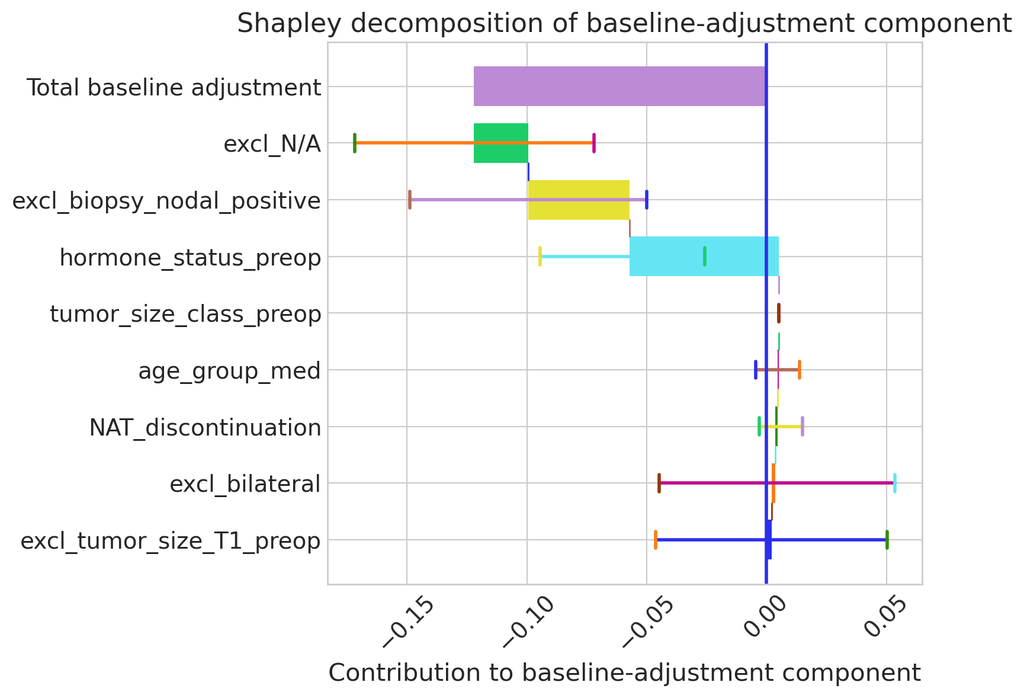

```python
plot_shapley_waterfall(
    shapley_summary_dict_mod,
    title="Shapley decomposition of baseline-adjustment component",
    #sort_by="abs",
    show_ci=True
)

fig.savefig(prefix_path + "Users/Per_Tra_analysis/Images/kristineB_shapley_waterfall_discont.pdf",
            bbox_inches="tight",
            facecolor="white")

plt.close()
```

```python
hormone_status_mean = shapley_summary_dict["hormone_status"]["mean"]

means = [r["mean"] for r in shapley_summary_dict.values()]

total_sum_shapley = np.sum(means)

print("Hormone status prop:")
print(hormone_status_mean/total_sum_shapley)
```

```
Hormone status prop:
0.5094487906427139
```

```python
hormone_status_mean = shapley_summary_dict["hormone_status"]["mean"]

means_excl_node_biopsy = [r["mean"] for k, r in shapley_summary_dict.items() if k != "biopsy_nodal_positive:True"]

total_sum_shapley_excl_node_biopsy = np.sum(means_excl_node_biopsy)

print("Hormone status prop if node biopsy true is 0:")
print(hormone_status_mean/total_sum_shapley_excl_node_biopsy)
```

```
Hormone status prop if node biopsy true is 0:
0.5094487906427139
```

```python
total_sum_shapley_abs = np.sum(np.abs(means))

print("Hormone status prop from absolute effects:")
print(np.abs(hormone_status_mean)/total_sum_shapley_abs)
```

```
Hormone status prop from absolute effects:
0.47039599117145037
```

```python
total_sum_shapley_abs_excl_node_biopsy = np.sum(np.abs(means_excl_node_biopsy))

print("Hormone status prop from absolute effects if node biopsy true is 0::")
print(np.abs(hormone_status_mean)/total_sum_shapley_abs_excl_node_biopsy)
```

```
Hormone status prop from absolute effects if node biopsy true is 0::
0.47039599117145037
```

```python
print("pCR rate all")
print(np.mean(y))
print("pCR rate nodal biopsy positive")
print(np.mean(y[per_tra["biopsy_nodal_positive"]=="True"]))
print("pCR rate nodal biopsy non-positive")
print(np.mean(y[per_tra["biopsy_nodal_positive"]=="False"]))

print("N all")
print(len(y))
print("N nodal biopsy positive")
print(len(y[per_tra["biopsy_nodal_positive"]=="False"]))

print("Mean date all")
print(pd.to_datetime(per_tra[per_tra["biopsy_nodal_positive"]=="False"]["Preop_pnb_date"], format='%m/%d/%Y').mean())
print("Mean date nodal biopsy positive")
print(pd.to_datetime(per_tra[per_tra["biopsy_nodal_positive"]=="False"]["Preop_pnb_date"], format='%m/%d/%Y').mean())


print("Prop of HR+ patiens in nodal biopsy positive")
print(idx_dict["hormone_status"][per_tra["biopsy_nodal_positive"]=="True"].mean())
print("Prop of HR+ patiens in nodal biopsy non-positive")
print(idx_dict["hormone_status"][per_tra["biopsy_nodal_positive"]=="False"].mean())
```

```
pCR rate all
0.5447761194029851
pCR rate nodal biopsy positive
0.589041095890411
pCR rate nodal biopsy non-positive
0.4918032786885246
N all
268
N nodal biopsy positive
122
Mean date all
2022-09-18 00:23:36.393442560
Mean date nodal biopsy positive
2022-09-18 00:23:36.393442560
Prop of HR+ patiens in nodal biopsy positive
0.2945205479452055
Prop of HR+ patiens in nodal biopsy non-positive
0.36885245901639346
```

# Posterior predictive diagnostics

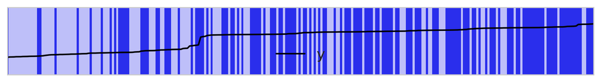

```python
az.plot_separation(idata=idata, y='y', y_hat='y', figsize=(8, 1), expected_events=False, y_hat_line=True)
```

```python
predicted_values = idata.posterior_predictive["y"].mean(dim=["chain", "draw"])

predicted = pd.DataFrame({"y":y.copy(),
                        "pred":predicted_values})
```

```python
true_pCR_mean = len(predicted[predicted["y"]==True])/len(predicted)
pred_pCR_mean = np.mean(predicted["pred"])

print("True pCR mean:")
print(true_pCR_mean)
print("Predicted pCR mean:")
print(pred_pCR_mean)
```

```
True pCR mean:
0.5447761194029851
Predicted pCR mean:
0.5442075337597726
```

```python
error_rate_model = np.mean(((predicted["pred"]>0.5) & (predicted["y"]==False))|((predicted["pred"]<0.5) & (predicted["y"]==True)))
pCR_rate_observed = np.mean(y)

if pCR_rate_observed < 0.5:
    error_rate_null = pCR_rate_observed
else:
    error_rate_null = 1-pCR_rate_observed

print("Model error rate: " + str(np.round(error_rate_model,3)))
print("Null model error rate: " + str(np.round(error_rate_null,3)))
print("Thus the predictive benefit of the model is " + str(np.round((error_rate_null - error_rate_model)*100,1)) + " %-points")
```

```
Model error rate: 0.328
Null model error rate: 0.455
Thus the predictive benefit of the model is 12.7 %-points
```

```python
predicted["residual"] = predicted["y"] - predicted["pred"]
```